# INN_Learner_Notebook_Full_code

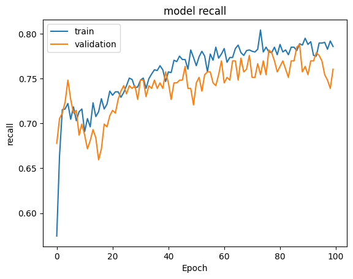

```python
#Plotting Train recall vs Validation recall
plt.plot(history_2.history['recall'])
plt.plot(history_2.history['val_recall'])
plt.title('model recall')
plt.ylabel('recall')
plt.xlabel('Epoch')
plt.legend(['train', 'validation'], loc='upper left')
plt.show()
```

```python
#Predicting the results using best as a threshold
y_train_pred = model_2.predict(X_train)
y_train_pred = (y_train_pred > 0.5)
y_train_pred
```

```
200/200 ━━━━━━━━━━━━━━━━━━━━ 1s 3ms/step
```

```
array([[ True],
       [False],
       [False],
       ...,
       [False],
       [ True],
       [False]])
```

```python
#Predicting the results using 0.5 as the threshold.
y_val_pred = model_2.predict(X_val)
y_val_pred = (y_val_pred > 0.5)
y_val_pred
```

```
50/50 ━━━━━━━━━━━━━━━━━━━━ 0s 5ms/step
```

```
array([[ True],
       [False],
       [False],
       ...,
       [False],
       [ True],
       [ True]])
```

```python
model_name = "NN with Adam & Dropout"

train_metric_df.loc[model_name] = recall_score(y_train,y_train_pred)
valid_metric_df.loc[model_name] = recall_score(y_val,y_val_pred)
```

**Classification report**

```python
#classification report
cr=classification_report(y_train,y_train_pred)
print(cr)
```

```
              precision    recall  f1-score   support

           0       0.95      0.81      0.87      5096
           1       0.53      0.82      0.64      1304

    accuracy                           0.81      6400
   macro avg       0.74      0.82      0.76      6400
weighted avg       0.86      0.81      0.83      6400
```

```python
#classification report on validation set
cr = classification_report(y_val, y_val_pred)
print(cr)
```

```
              precision    recall  f1-score   support

           0       0.93      0.79      0.85      1274
           1       0.48      0.76      0.59       326

    accuracy                           0.79      1600
   macro avg       0.71      0.78      0.72      1600
weighted avg       0.84      0.79      0.80      1600
```

**Confusion matrix**

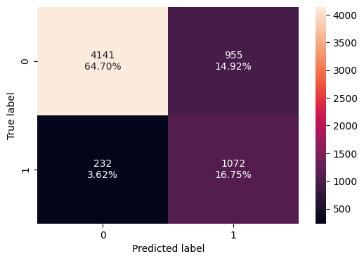

```python
#Calculating the confusion matrix
make_confusion_matrix(y_train, y_train_pred)
```

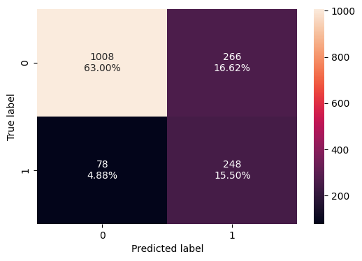

```python
#Calculating the confusion matrix val set
make_confusion_matrix(y_val, y_val_pred)
```

### Neural Network with Balanced Data (by applying SMOTE) and SGD Optimizer

**Apply SMOTE to balance this dataset**

```python
sm  = SMOTE(random_state=42)
#Code to fit SMOTE on the training data.
X_train_smote, y_train_smote= sm.fit_resample(X_train, y_train)
print(X_train_smote.shape,  y_train_smote.shape)
```

```
(10192, 11) (10192,)
```

**Build a model with the balanced dataset**

```python
backend.clear_session()
#Fixing the seed for random number generators so that we can ensure we receive the same output everytime
np.random.seed(2)
random.seed(2)
tf.random.set_seed(2)
```

```python
#Initializing the model
model_3 = Sequential()
#Code to add a input layer
model_3.add(Dense(32,activation='relu',input_dim = X_train_smote.shape[1]))
#Code to add a hidden layer
model_3.add(Dense(16,activation='relu'))
#Code to add a hidden layer
model_3.add(Dense(4,activation='relu'))
# Code to add the required number of neurons in the output layer with a sigmoid activation function.
model_3.add(Dense(1, activation = 'sigmoid'))
```

```python
#Complete the code to use SGD as the optimizer.
optimizer = tf.keras.optimizers.SGD(0.001)

metric = keras.metrics.Recall()
```

```python
# Code to compile the model with binary cross entropy as loss function and recall as the metric
model_3.compile(loss='binary_crossentropy',optimizer=optimizer,metrics=[metric])
```

```python
model_3.summary()
```

```
Model: "sequential"
```

```
┏━━━━━━━━━━━━━━━━━━━━━━━━━━━━━━━━━━━━━━┳━━━━━━━━━━━━━━━━━━━━━━━━━━━━━┳━━━━━━━━━━━━━━━━━┓
┃ Layer (type)                         ┃ Output Shape                ┃         Param # ┃
┡━━━━━━━━━━━━━━━━━━━━━━━━━━━━━━━━━━━━━━╇━━━━━━━━━━━━━━━━━━━━━━━━━━━━━╇━━━━━━━━━━━━━━━━━┩
│ dense (Dense)                        │ (None, 32)                  │             384 │
├──────────────────────────────────────┼─────────────────────────────┼─────────────────┤
│ dense_1 (Dense)                      │ (None, 16)                  │             528 │
├──────────────────────────────────────┼─────────────────────────────┼─────────────────┤
│ dense_2 (Dense)                      │ (None, 4)                   │              68 │
├──────────────────────────────────────┼─────────────────────────────┼─────────────────┤
│ dense_3 (Dense)                      │ (None, 1)                   │               5 │
└──────────────────────────────────────┴─────────────────────────────┴─────────────────┘
```

```
 Total params: 985 (3.85 KB)
```

```
 Trainable params: 985 (3.85 KB)
```

```
 Non-trainable params: 0 (0.00 B)
```

```python
#Fitting the ANN
history_3 = model_3.fit(X_train_smote, y_train_smote,batch_size=batch_size, epochs=epochs, validation_data = (X_val,y_val), verbose=1)
```

```
160/160 ━━━━━━━━━━━━━━━━━━━━ 1s 4ms/step - loss: 0.6987 - recall: 0.9886 - val_loss: 0.7454 - val_recall: 0.9785
160/160 ━━━━━━━━━━━━━━━━━━━━ 0s 2ms/step - loss: 0.6958 - recall: 0.9813 - val_loss: 0.7384 - val_recall: 0.9632
160/160 ━━━━━━━━━━━━━━━━━━━━ 1s 2ms/step - loss: 0.6938 - recall: 0.9711 - val_loss: 0.7334 - val_recall: 0.9509
160/160 ━━━━━━━━━━━━━━━━━━━━ 1s 2ms/step - loss: 0.6921 - recall: 0.9564 - val_loss: 0.7296 - val_recall: 0.9387
160/160 ━━━━━━━━━━━━━━━━━━━━ 1s 2ms/step - loss: 0.6907 - recall: 0.9444 - val_loss: 0.7268 - val_recall: 0.9264
160/160 ━━━━━━━━━━━━━━━━━━━━ 1s 2ms/step - loss: 0.6893 - recall: 0.9338 - val_loss: 0.7244 - val_recall: 0.9110
160/160 ━━━━━━━━━━━━━━━━━━━━ 1s 2ms/step - loss: 0.6880 - recall: 0.9240 - val_loss: 0.7224 - val_recall: 0.9080
160/160 ━━━━━━━━━━━━━━━━━━━━ 1s 2ms/step - loss: 0.6868 - recall: 0.9142 - val_loss: 0.7208 - val_recall: 0.9110
160/160 ━━━━━━━━━━━━━━━━━━━━ 1s 2ms/step - loss: 0.6855 - recall: 0.9034 - val_loss: 0.7195 - val_recall: 0.9080
160/160 ━━━━━━━━━━━━━━━━━━━━ 1s 2ms/step - loss: 0.6842 - recall: 0.8957 - val_loss: 0.7184 - val_recall: 0.8957
160/160 ━━━━━━━━━━━━━━━━━━━━ 1s 2ms/step - loss: 0.6829 - recall: 0.8940 - val_loss: 0.7176 - val_recall: 0.8834
160/160 ━━━━━━━━━━━━━━━━━━━━ 1s 2ms/step - loss: 0.6816 - recall: 0.8868 - val_loss: 0.7169 - val_recall: 0.8865
160/160 ━━━━━━━━━━━━━━━━━━━━ 1s 2ms/step - loss: 0.6802 - recall: 0.8815 - val_loss: 0.7163 - val_recall: 0.8896
160/160 ━━━━━━━━━━━━━━━━━━━━ 1s 2ms/step - loss: 0.6788 - recall: 0.8784 - val_loss: 0.7157 - val_recall: 0.8896
160/160 ━━━━━━━━━━━━━━━━━━━━ 1s 3ms/step - loss: 0.6774 - recall: 0.8742 - val_loss: 0.7151 - val_recall: 0.8865
160/160 ━━━━━━━━━━━━━━━━━━━━ 1s 4ms/step - loss: 0.6761 - recall: 0.8698 - val_loss: 0.7146 - val_recall: 0.8804
160/160 ━━━━━━━━━━━━━━━━━━━━ 1s 3ms/step - loss: 0.6747 - recall: 0.8681 - val_loss: 0.7139 - val_recall: 0.8650
160/160 ━━━━━━━━━━━━━━━━━━━━ 1s 4ms/step - loss: 0.6733 - recall: 0.8654 - val_loss: 0.7132 - val_recall: 0.8650
160/160 ━━━━━━━━━━━━━━━━━━━━ 1s 3ms/step - loss: 0.6720 - recall: 0.8587 - val_loss: 0.7126 - val_recall: 0.8650
160/160 ━━━━━━━━━━━━━━━━━━━━ 1s 4ms/step - loss: 0.6706 - recall: 0.8532 - val_loss: 0.7119 - val_recall: 0.8589
160/160 ━━━━━━━━━━━━━━━━━━━━ 0s 2ms/step - loss: 0.6693 - recall: 0.8509 - val_loss: 0.7112 - val_recall: 0.8528
160/160 ━━━━━━━━━━━━━━━━━━━━ 1s 2ms/step - loss: 0.6679 - recall: 0.8482 - val_loss: 0.7106 - val_recall: 0.8497
160/160 ━━━━━━━━━━━━━━━━━━━━ 0s 2ms/step - loss: 0.6665 - recall: 0.8404 - val_loss: 0.7099 - val_recall: 0.8405
160/160 ━━━━━━━━━━━━━━━━━━━━ 1s 2ms/step - loss: 0.6652 - recall: 0.8323 - val_loss: 0.7091 - val_recall: 0.8344
160/160 ━━━━━━━━━━━━━━━━━━━━ 0s 2ms/step - loss: 0.6638 - recall: 0.8291 - val_loss: 0.7084 - val_recall: 0.8190
```

**Loss function**

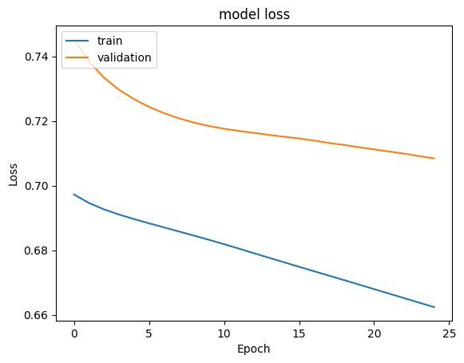

```python
#Plotting Train Loss vs Validation Loss
plt.plot(history_3.history['loss'])
plt.plot(history_3.history['val_loss'])
plt.title('model loss')
plt.ylabel('Loss')
plt.xlabel('Epoch')
plt.legend(['train', 'validation'], loc='upper left')
plt.show()
```

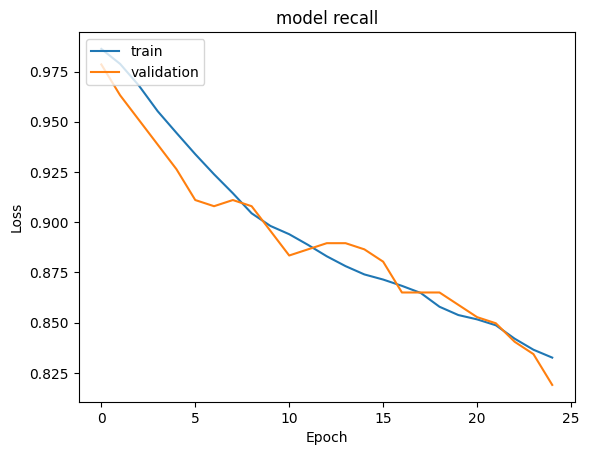

```python
#Plotting Train recall vs Validation recall
plt.plot(history_3.history['recall'])
plt.plot(history_3.history['val_recall'])
plt.title('model recall')
plt.ylabel('Loss')
plt.xlabel('Epoch')
plt.legend(['train', 'validation'], loc='upper left')
plt.show()
```

```python
y_train_pred = model_3.predict(X_train_smote)
#Predicting the results using 0.5 as the threshold
y_train_pred = (y_train_pred > 0.5)
y_train_pred
```

```
319/319 ━━━━━━━━━━━━━━━━━━━━ 1s 1ms/step
```

```
array([[ True],
       [ True],
       [ True],
       ...,
       [False],
       [ True],
       [ True]])
```

```python
y_val_pred = model_3.predict(X_val)
#Predicting the results using 0.5 as the threshold
y_val_pred = (y_val_pred > 0.5)
y_val_pred
```

```
50/50 ━━━━━━━━━━━━━━━━━━━━ 0s 2ms/step
```

```
array([[ True],
       [False],
       [False],
       ...,
       [False],
       [ True],
       [ True]])
```

```python
model_name = "NN with SMOTE & SGD"

train_metric_df.loc[model_name] = recall_score(y_train_smote,y_train_pred)
valid_metric_df.loc[model_name] = recall_score(y_val,y_val_pred)
```

**Classification report**

```python
cr=classification_report(y_train_smote,y_train_pred)
print(cr)
```

```
              precision    recall  f1-score   support

           0       0.73      0.45      0.55      5096
           1       0.60      0.83      0.70      5096

    accuracy                           0.64     10192
   macro avg       0.66      0.64      0.63     10192
weighted avg       0.66      0.64      0.63     10192
```

```python
cr=classification_report(y_val,y_val_pred)
print(cr)
```

```
              precision    recall  f1-score   support

           0       0.91      0.45      0.60      1274
           1       0.27      0.82      0.41       326

    accuracy                           0.52      1600
   macro avg       0.59      0.63      0.51      1600
weighted avg       0.78      0.52      0.56      1600
```

**Confusion matrix**

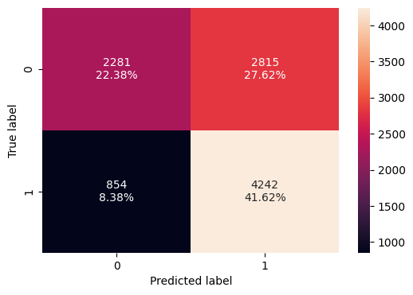

```python
#Calculating the confusion matrix
make_confusion_matrix(y_train_smote, y_train_pred)
```

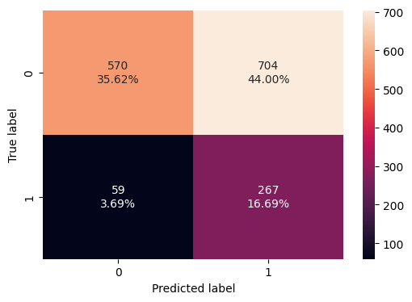

```python
#Calculating the confusion matrix on the validation set

make_confusion_matrix(y_val,y_val_pred)
```

### Neural Network with Balanced Data (by applying SMOTE) and Adam Optimizer

```python
backend.clear_session()
#Fixing the seed for random number generators so that we can ensure we receive the same output everytime
np.random.seed(2)
random.seed(2)
tf.random.set_seed(2)
```

```python
#Initializing the model
model_4 = Sequential()
#Code to add a input layer
model_4.add(Dense(32,activation='relu',input_dim = X_train_smote.shape[1]))
#Code to add a hidden layer
model_4.add(Dense(16,activation='relu'))
#Code to add a hidden layer
model_4.add(Dense(4,activation='relu'))
# Code to add the required number of neurons in the output layer and a suitable activation function.
model_4.add(Dense(1, activation = 'sigmoid'))
```

```python
#Complete the code to use Adam as the optimizer.
optimizer = tf.keras.optimizers.Adam()

metric = keras.metrics.Recall()
```

```python
# Code to compile the model with binary cross entropy as loss function and recall as the metric
model_4.compile(loss='binary_crossentropy',optimizer=optimizer,metrics=[metric])
```

```python
model_4.summary()
```

```
Model: "sequential"
```

```
┏━━━━━━━━━━━━━━━━━━━━━━━━━━━━━━━━━━━━━━┳━━━━━━━━━━━━━━━━━━━━━━━━━━━━━┳━━━━━━━━━━━━━━━━━┓
┃ Layer (type)                         ┃ Output Shape                ┃         Param # ┃
┡━━━━━━━━━━━━━━━━━━━━━━━━━━━━━━━━━━━━━━╇━━━━━━━━━━━━━━━━━━━━━━━━━━━━━╇━━━━━━━━━━━━━━━━━┩
│ dense (Dense)                        │ (None, 32)                  │             384 │
├──────────────────────────────────────┼─────────────────────────────┼─────────────────┤
│ dense_1 (Dense)                      │ (None, 16)                  │             528 │
├──────────────────────────────────────┼─────────────────────────────┼─────────────────┤
│ dense_2 (Dense)                      │ (None, 4)                   │              68 │
├──────────────────────────────────────┼─────────────────────────────┼─────────────────┤
│ dense_3 (Dense)                      │ (None, 1)                   │               5 │
└──────────────────────────────────────┴─────────────────────────────┴─────────────────┘
```

```
 Total params: 985 (3.85 KB)
```

```
 Trainable params: 985 (3.85 KB)
```

```
 Non-trainable params: 0 (0.00 B)
```

```python
#Fitting the ANN

history_4 = model_4.fit(X_train_smote,y_train_smote,batch_size=32, epochs=100,  validation_data = (X_val,y_val), verbose=1)
```

```
319/319 ━━━━━━━━━━━━━━━━━━━━ 3s 4ms/step - loss: 0.6653 - recall: 0.9002 - val_loss: 0.7034 - val_recall: 0.7577
319/319 ━━━━━━━━━━━━━━━━━━━━ 2s 3ms/step - loss: 0.6058 - recall: 0.7602 - val_loss: 0.6644 - val_recall: 0.6871
319/319 ━━━━━━━━━━━━━━━━━━━━ 1s 2ms/step - loss: 0.5711 - recall: 0.7355 - val_loss: 0.6372 - val_recall: 0.6748
319/319 ━━━━━━━━━━━━━━━━━━━━ 1s 2ms/step - loss: 0.5432 - recall: 0.7416 - val_loss: 0.6066 - val_recall: 0.6840
319/319 ━━━━━━━━━━━━━━━━━━━━ 1s 2ms/step - loss: 0.5216 - recall: 0.7536 - val_loss: 0.5918 - val_recall: 0.7239
319/319 ━━━━━━━━━━━━━━━━━━━━ 1s 2ms/step - loss: 0.5023 - recall: 0.7684 - val_loss: 0.5732 - val_recall: 0.7270
319/319 ━━━━━━━━━━━━━━━━━━━━ 1s 2ms/step - loss: 0.4856 - recall: 0.7824 - val_loss: 0.5584 - val_recall: 0.7423
319/319 ━━━━━━━━━━━━━━━━━━━━ 1s 2ms/step - loss: 0.4701 - recall: 0.7898 - val_loss: 0.5446 - val_recall: 0.7515
319/319 ━━━━━━━━━━━━━━━━━━━━ 1s 2ms/step - loss: 0.4558 - recall: 0.7924 - val_loss: 0.5245 - val_recall: 0.7577
319/319 ━━━━━━━━━━━━━━━━━━━━ 1s 2ms/step - loss: 0.4446 - recall: 0.7993 - val_loss: 0.5153 - val_recall: 0.7577
319/319 ━━━━━━━━━━━━━━━━━━━━ 1s 2ms/step - loss: 0.4362 - recall: 0.8011 - val_loss: 0.5010 - val_recall: 0.7546
319/319 ━━━━━━━━━━━━━━━━━━━━ 1s 2ms/step - loss: 0.4294 - recall: 0.8082 - val_loss: 0.4974 - val_recall: 0.7638
319/319 ━━━━━━━━━━━━━━━━━━━━ 2s 4ms/step - loss: 0.4236 - recall: 0.8099 - val_loss: 0.4884 - val_recall: 0.7577
319/319 ━━━━━━━━━━━━━━━━━━━━ 2s 3ms/step - loss: 0.4179 - recall: 0.8121 - val_loss: 0.4852 - val_recall: 0.7546
319/319 ━━━━━━━━━━━━━━━━━━━━ 1s 2ms/step - loss: 0.4132 - recall: 0.8148 - val_loss: 0.4816 - val_recall: 0.7485
319/319 ━━━━━━━━━━━━━━━━━━━━ 1s 2ms/step - loss: 0.4092 - recall: 0.8164 - val_loss: 0.4819 - val_recall: 0.7485
319/319 ━━━━━━━━━━━━━━━━━━━━ 1s 2ms/step - loss: 0.4056 - recall: 0.8179 - val_loss: 0.4753 - val_recall: 0.7454
319/319 ━━━━━━━━━━━━━━━━━━━━ 1s 2ms/step - loss: 0.4019 - recall: 0.8202 - val_loss: 0.4757 - val_recall: 0.7546
319/319 ━━━━━━━━━━━━━━━━━━━━ 1s 2ms/step - loss: 0.3985 - recall: 0.8207 - val_loss: 0.4749 - val_recall: 0.7515
319/319 ━━━━━━━━━━━━━━━━━━━━ 1s 2ms/step - loss: 0.3956 - recall: 0.8230 - val_loss: 0.4750 - val_recall: 0.7485
319/319 ━━━━━━━━━━━━━━━━━━━━ 1s 2ms/step - loss: 0.3929 - recall: 0.8243 - val_loss: 0.4730 - val_recall: 0.7485
319/319 ━━━━━━━━━━━━━━━━━━━━ 1s 2ms/step - loss: 0.3905 - recall: 0.8292 - val_loss: 0.4729 - val_recall: 0.7423
319/319 ━━━━━━━━━━━━━━━━━━━━ 1s 2ms/step - loss: 0.3882 - recall: 0.8313 - val_loss: 0.4760 - val_recall: 0.7423
319/319 ━━━━━━━━━━━━━━━━━━━━ 1s 2ms/step - loss: 0.3857 - recall: 0.8322 - val_loss: 0.4739 - val_recall: 0.7485
319/319 ━━━━━━━━━━━━━━━━━━━━ 1s 2ms/step - loss: 0.3837 - recall: 0.8309 - val_loss: 0.4764 - val_recall: 0.7485
319/319 ━━━━━━━━━━━━━━━━━━━━ 1s 4ms/step - loss: 0.3816 - recall: 0.8324 - val_loss: 0.4805 - val_recall: 0.7515
319/319 ━━━━━━━━━━━━━━━━━━━━ 3s 4ms/step - loss: 0.3794 - recall: 0.8316 - val_loss: 0.4778 - val_recall: 0.7423
319/319 ━━━━━━━━━━━━━━━━━━━━ 3s 4ms/step - loss: 0.3775 - recall: 0.8335 - val_loss: 0.4785 - val_recall: 0.7393
319/319 ━━━━━━━━━━━━━━━━━━━━ 2s 2ms/step - loss: 0.3757 - recall: 0.8350 - val_loss: 0.4784 - val_recall: 0.7362
319/319 ━━━━━━━━━━━━━━━━━━━━ 1s 2ms/step - loss: 0.3736 - recall: 0.8356 - val_loss: 0.4752 - val_recall: 0.7331
319/319 ━━━━━━━━━━━━━━━━━━━━ 1s 2ms/step - loss: 0.3716 - recall: 0.8375 - val_loss: 0.4752 - val_recall: 0.7393
319/319 ━━━━━━━━━━━━━━━━━━━━ 1s 2ms/step - loss: 0.3693 - recall: 0.8395 - val_loss: 0.4769 - val_recall: 0.7331
319/319 ━━━━━━━━━━━━━━━━━━━━ 1s 2ms/step - loss: 0.3677 - recall: 0.8421 - val_loss: 0.4807 - val_recall: 0.7393
319/319 ━━━━━━━━━━━━━━━━━━━━ 1s 2ms/step - loss: 0.3660 - recall: 0.8437 - val_loss: 0.4771 - val_recall: 0.7301
319/319 ━━━━━━━━━━━━━━━━━━━━ 1s 2ms/step - loss: 0.3646 - recall: 0.8470 - val_loss: 0.4811 - val_recall: 0.7423
319/319 ━━━━━━━━━━━━━━━━━━━━ 1s 2ms/step - loss: 0.3629 - recall: 0.8474 - val_loss: 0.4788 - val_recall: 0.7301
319/319 ━━━━━━━━━━━━━━━━━━━━ 1s 2ms/step - loss: 0.3614 - recall: 0.8500 - val_loss: 0.4798 - val_recall: 0.7331
319/319 ━━━━━━━━━━━━━━━━━━━━ 2s 3ms/step - loss: 0.3601 - recall: 0.8501 - val_loss: 0.4800 - val_recall: 0.7301
319/319 ━━━━━━━━━━━━━━━━━━━━ 1s 3ms/step - loss: 0.3586 - recall: 0.8521 - val_loss: 0.4819 - val_recall: 0.7209
319/319 ━━━━━━━━━━━━━━━━━━━━ 1s 3ms/step - loss: 0.3568 - recall: 0.8517 - val_loss: 0.4840 - val_recall: 0.7362
```

[output cut: 45 more lines]

```
319/319 ━━━━━━━━━━━━━━━━━━━━ 1s 2ms/step - loss: 0.3130 - recall: 0.8745 - val_loss: 0.5404 - val_recall: 0.7178
319/319 ━━━━━━━━━━━━━━━━━━━━ 1s 2ms/step - loss: 0.3122 - recall: 0.8760 - val_loss: 0.5371 - val_recall: 0.7147
319/319 ━━━━━━━━━━━━━━━━━━━━ 2s 4ms/step - loss: 0.3119 - recall: 0.8740 - val_loss: 0.5388 - val_recall: 0.7178
319/319 ━━━━━━━━━━━━━━━━━━━━ 1s 4ms/step - loss: 0.3108 - recall: 0.8767 - val_loss: 0.5396 - val_recall: 0.7117
319/319 ━━━━━━━━━━━━━━━━━━━━ 2s 2ms/step - loss: 0.3108 - recall: 0.8763 - val_loss: 0.5416 - val_recall: 0.7147
319/319 ━━━━━━━━━━━━━━━━━━━━ 1s 3ms/step - loss: 0.3099 - recall: 0.8767 - val_loss: 0.5389 - val_recall: 0.7117
319/319 ━━━━━━━━━━━━━━━━━━━━ 1s 3ms/step - loss: 0.3093 - recall: 0.8771 - val_loss: 0.5419 - val_recall: 0.7178
319/319 ━━━━━━━━━━━━━━━━━━━━ 1s 3ms/step - loss: 0.3092 - recall: 0.8781 - val_loss: 0.5421 - val_recall: 0.7178
319/319 ━━━━━━━━━━━━━━━━━━━━ 1s 2ms/step - loss: 0.3080 - recall: 0.8771 - val_loss: 0.5407 - val_recall: 0.7147
319/319 ━━━━━━━━━━━━━━━━━━━━ 1s 2ms/step - loss: 0.3075 - recall: 0.8766 - val_loss: 0.5423 - val_recall: 0.7147
319/319 ━━━━━━━━━━━━━━━━━━━━ 1s 2ms/step - loss: 0.3069 - recall: 0.8780 - val_loss: 0.5429 - val_recall: 0.7117
319/319 ━━━━━━━━━━━━━━━━━━━━ 1s 2ms/step - loss: 0.3067 - recall: 0.8765 - val_loss: 0.5418 - val_recall: 0.7178
319/319 ━━━━━━━━━━━━━━━━━━━━ 1s 2ms/step - loss: 0.3061 - recall: 0.8765 - val_loss: 0.5394 - val_recall: 0.7086
319/319 ━━━━━━━━━━━━━━━━━━━━ 1s 2ms/step - loss: 0.3058 - recall: 0.8789 - val_loss: 0.5385 - val_recall: 0.7055
319/319 ━━━━━━━━━━━━━━━━━━━━ 1s 4ms/step - loss: 0.3049 - recall: 0.8806 - val_loss: 0.5425 - val_recall: 0.7086
```

**Loss function**

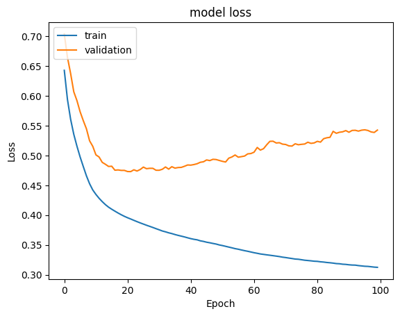

```python
#Plotting Train Loss vs Validation Loss
plt.plot(history_4.history['loss'])
plt.plot(history_4.history['val_loss'])
plt.title('model loss')
plt.ylabel('Loss')
plt.xlabel('Epoch')
plt.legend(['train', 'validation'], loc='upper left')
plt.show()
```

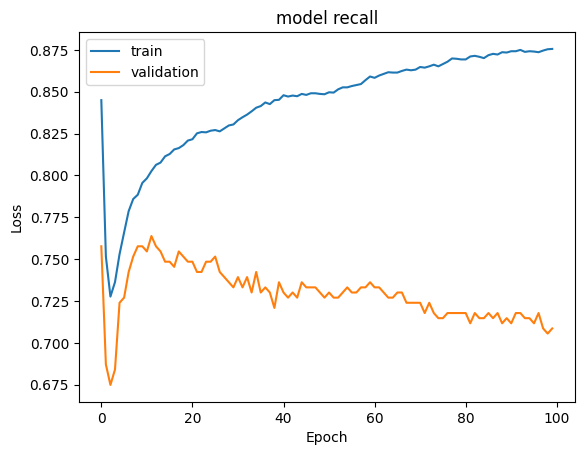

```python
#Plotting Train recall vs Validation recall
plt.plot(history_4.history['recall'])
plt.plot(history_4.history['val_recall'])
plt.title('model recall')
plt.ylabel('Loss')
plt.xlabel('Epoch')
plt.legend(['train', 'validation'], loc='upper left')
plt.show()
```

```python
y_train_pred = model_4.predict(X_train_smote)
#Predicting the results using 0.5 as the threshold
y_train_pred = (y_train_pred > 0.5)
y_train_pred
```

```
319/319 ━━━━━━━━━━━━━━━━━━━━ 1s 1ms/step
```

```
array([[ True],
       [False],
       [False],
       ...,
       [ True],
       [ True],
       [ True]])
```

```python
y_val_pred = model_4.predict(X_val)
#Predicting the results using 0.5 as the threshold
y_val_pred = (y_val_pred > 0.5)
y_val_pred
```

```
50/50 ━━━━━━━━━━━━━━━━━━━━ 0s 1ms/step
```

```
array([[False],
       [False],
       [False],
       ...,
       [False],
       [ True],
       [ True]])
```

```python
model_name = "NN with SMOTE & Adam"

train_metric_df.loc[model_name] = recall_score(y_train_smote,y_train_pred)
valid_metric_df.loc[model_name] = recall_score(y_val,y_val_pred)
```

**Classification report**

```python
cr=classification_report(y_train_smote,y_train_pred)
print(cr)
```

```
              precision    recall  f1-score   support

           0       0.90      0.83      0.87      5096
           1       0.84      0.91      0.88      5096

    accuracy                           0.87     10192
   macro avg       0.87      0.87      0.87     10192
weighted avg       0.87      0.87      0.87     10192
```

```python
cr=classification_report(y_val, y_val_pred)
print(cr)
```

```
              precision    recall  f1-score   support

           0       0.92      0.81      0.86      1274
           1       0.48      0.71      0.57       326

    accuracy                           0.79      1600
   macro avg       0.70      0.76      0.72      1600
weighted avg       0.83      0.79      0.80      1600
```

**Confusion matrix**

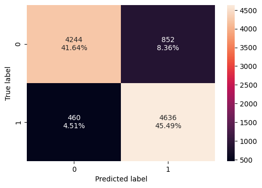

```python
#Calculating the confusion matrix
make_confusion_matrix(y_train_smote, y_train_pred)
```

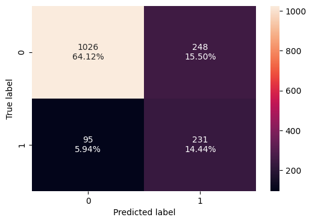

```python
#Calculating the confusion matrix on the validation set
make_confusion_matrix(y_val,y_val_pred)
```

```python
backend.clear_session()
#Fixing the seed for random number generators so that we can ensure we receive the same output everytime
np.random.seed(2)
random.seed(2)
tf.random.set_seed(2)
```

```python
#Initializing the model
model_5 = Sequential()
# Code to add required 32 of neurons to the input layer with relu as activation function
model_5.add(Dense(32,activation='relu',input_dim = X_train_smote.shape[1]))
#Code to add dropout rate
model_5.add(Dropout(0.2))
# Code to add required 16 neurons to the hidden layer with any activation function.
model_5.add(Dense(16,activation='relu'))
# Code to add dropout rate.
model_5.add(Dropout(0.1))
# Adding hidden layer with 8 neurons with relu as activation function
model_5.add(Dense(8,activation='relu'))
# Code to add the required number of neurons in the output layer with a suitable activation function.
model_5.add(Dense(1, activation = 'sigmoid'))
```

```python
#Complete the code to use Adam as the optimizer.
optimizer = tf.keras.optimizers.Adam()

metric = keras.metrics.Recall()
```

```python
# Code to compile the model with binary cross entropy as loss function and recall as the metric
model_5.compile(loss='binary_crossentropy',optimizer=optimizer,metrics=[metric])
```

```python
model_5.summary()
```

```
Model: "sequential"
```

```
┏━━━━━━━━━━━━━━━━━━━━━━━━━━━━━━━━━━━━━━┳━━━━━━━━━━━━━━━━━━━━━━━━━━━━━┳━━━━━━━━━━━━━━━━━┓
┃ Layer (type)                         ┃ Output Shape                ┃         Param # ┃
┡━━━━━━━━━━━━━━━━━━━━━━━━━━━━━━━━━━━━━━╇━━━━━━━━━━━━━━━━━━━━━━━━━━━━━╇━━━━━━━━━━━━━━━━━┩
│ dense (Dense)                        │ (None, 32)                  │             384 │
├──────────────────────────────────────┼─────────────────────────────┼─────────────────┤
│ dropout (Dropout)                    │ (None, 32)                  │               0 │
├──────────────────────────────────────┼─────────────────────────────┼─────────────────┤
│ dense_1 (Dense)                      │ (None, 16)                  │             528 │
├──────────────────────────────────────┼─────────────────────────────┼─────────────────┤
│ dropout_1 (Dropout)                  │ (None, 16)                  │               0 │
├──────────────────────────────────────┼─────────────────────────────┼─────────────────┤
│ dense_2 (Dense)                      │ (None, 8)                   │             136 │
├──────────────────────────────────────┼─────────────────────────────┼─────────────────┤
│ dense_3 (Dense)                      │ (None, 1)                   │               9 │
└──────────────────────────────────────┴─────────────────────────────┴─────────────────┘
```

```
 Total params: 1,057 (4.13 KB)
```

```
 Trainable params: 1,057 (4.13 KB)
```

```
 Non-trainable params: 0 (0.00 B)
```

```python
history_5 = model_5.fit(X_train,y_train, batch_size=32, validation_data=(X_val,y_val), epochs=100, verbose=1, class_weight=cw_dict)
```

```
200/200 ━━━━━━━━━━━━━━━━━━━━ 4s 7ms/step - loss: 1.3720 - recall: 0.5634 - val_loss: 0.6068 - val_recall: 0.6718
200/200 ━━━━━━━━━━━━━━━━━━━━ 2s 2ms/step - loss: 1.2220 - recall: 0.7028 - val_loss: 0.5823 - val_recall: 0.6994
200/200 ━━━━━━━━━━━━━━━━━━━━ 1s 2ms/step - loss: 1.1800 - recall: 0.7008 - val_loss: 0.5739 - val_recall: 0.7025
200/200 ━━━━━━━━━━━━━━━━━━━━ 1s 2ms/step - loss: 1.1590 - recall: 0.7172 - val_loss: 0.5624 - val_recall: 0.7055
200/200 ━━━━━━━━━━━━━━━━━━━━ 1s 2ms/step - loss: 1.1379 - recall: 0.7359 - val_loss: 0.5592 - val_recall: 0.7055
200/200 ━━━━━━━━━━━━━━━━━━━━ 1s 2ms/step - loss: 1.1374 - recall: 0.7214 - val_loss: 0.5498 - val_recall: 0.6933
200/200 ━━━━━━━━━━━━━━━━━━━━ 0s 2ms/step - loss: 1.1201 - recall: 0.7461 - val_loss: 0.5488 - val_recall: 0.7086
200/200 ━━━━━━━━━━━━━━━━━━━━ 1s 2ms/step - loss: 1.1077 - recall: 0.7299 - val_loss: 0.5465 - val_recall: 0.7117
200/200 ━━━━━━━━━━━━━━━━━━━━ 0s 2ms/step - loss: 1.0935 - recall: 0.7362 - val_loss: 0.5296 - val_recall: 0.6748
200/200 ━━━━━━━━━━━━━━━━━━━━ 0s 2ms/step - loss: 1.0957 - recall: 0.7167 - val_loss: 0.5351 - val_recall: 0.6933
200/200 ━━━━━━━━━━━━━━━━━━━━ 0s 2ms/step - loss: 1.0910 - recall: 0.6992 - val_loss: 0.5303 - val_recall: 0.6840
200/200 ━━━━━━━━━━━━━━━━━━━━ 1s 2ms/step - loss: 1.0638 - recall: 0.7281 - val_loss: 0.5223 - val_recall: 0.6933
200/200 ━━━━━━━━━━━━━━━━━━━━ 1s 2ms/step - loss: 1.0693 - recall: 0.6982 - val_loss: 0.5206 - val_recall: 0.6902
200/200 ━━━━━━━━━━━━━━━━━━━━ 1s 2ms/step - loss: 1.0482 - recall: 0.7342 - val_loss: 0.5089 - val_recall: 0.6994
200/200 ━━━━━━━━━━━━━━━━━━━━ 1s 3ms/step - loss: 1.0469 - recall: 0.7198 - val_loss: 0.5059 - val_recall: 0.7178
200/200 ━━━━━━━━━━━━━━━━━━━━ 1s 2ms/step - loss: 1.0386 - recall: 0.7231 - val_loss: 0.4992 - val_recall: 0.7025
200/200 ━━━━━━━━━━━━━━━━━━━━ 0s 2ms/step - loss: 1.0133 - recall: 0.7182 - val_loss: 0.4991 - val_recall: 0.7331
200/200 ━━━━━━━━━━━━━━━━━━━━ 1s 3ms/step - loss: 1.0117 - recall: 0.7311 - val_loss: 0.4839 - val_recall: 0.7025
200/200 ━━━━━━━━━━━━━━━━━━━━ 1s 5ms/step - loss: 1.0214 - recall: 0.7121 - val_loss: 0.4898 - val_recall: 0.7209
200/200 ━━━━━━━━━━━━━━━━━━━━ 1s 4ms/step - loss: 0.9787 - recall: 0.7531 - val_loss: 0.4771 - val_recall: 0.7270
200/200 ━━━━━━━━━━━━━━━━━━━━ 1s 4ms/step - loss: 1.0081 - recall: 0.7316 - val_loss: 0.4785 - val_recall: 0.7178
200/200 ━━━━━━━━━━━━━━━━━━━━ 1s 3ms/step - loss: 0.9867 - recall: 0.7364 - val_loss: 0.4750 - val_recall: 0.7301
200/200 ━━━━━━━━━━━━━━━━━━━━ 1s 2ms/step - loss: 0.9784 - recall: 0.7457 - val_loss: 0.4728 - val_recall: 0.7393
200/200 ━━━━━━━━━━━━━━━━━━━━ 1s 2ms/step - loss: 0.9687 - recall: 0.7502 - val_loss: 0.4687 - val_recall: 0.7331
200/200 ━━━━━━━━━━━━━━━━━━━━ 1s 2ms/step - loss: 0.9852 - recall: 0.7479 - val_loss: 0.4661 - val_recall: 0.7454
200/200 ━━━━━━━━━━━━━━━━━━━━ 1s 2ms/step - loss: 0.9602 - recall: 0.7528 - val_loss: 0.4706 - val_recall: 0.7423
200/200 ━━━━━━━━━━━━━━━━━━━━ 0s 2ms/step - loss: 0.9606 - recall: 0.7467 - val_loss: 0.4738 - val_recall: 0.7485
200/200 ━━━━━━━━━━━━━━━━━━━━ 1s 3ms/step - loss: 0.9706 - recall: 0.7566 - val_loss: 0.4651 - val_recall: 0.7515
200/200 ━━━━━━━━━━━━━━━━━━━━ 0s 2ms/step - loss: 0.9605 - recall: 0.7429 - val_loss: 0.4688 - val_recall: 0.7638
200/200 ━━━━━━━━━━━━━━━━━━━━ 0s 2ms/step - loss: 0.9565 - recall: 0.7587 - val_loss: 0.4574 - val_recall: 0.7454
200/200 ━━━━━━━━━━━━━━━━━━━━ 0s 2ms/step - loss: 0.9362 - recall: 0.7598 - val_loss: 0.4625 - val_recall: 0.7669
200/200 ━━━━━━━━━━━━━━━━━━━━ 1s 2ms/step - loss: 0.9433 - recall: 0.7643 - val_loss: 0.4638 - val_recall: 0.7730
200/200 ━━━━━━━━━━━━━━━━━━━━ 0s 2ms/step - loss: 0.9464 - recall: 0.7556 - val_loss: 0.4580 - val_recall: 0.7669
200/200 ━━━━━━━━━━━━━━━━━━━━ 1s 2ms/step - loss: 0.9373 - recall: 0.7524 - val_loss: 0.4567 - val_recall: 0.7669
200/200 ━━━━━━━━━━━━━━━━━━━━ 1s 2ms/step - loss: 0.9380 - recall: 0.7535 - val_loss: 0.4521 - val_recall: 0.7423
200/200 ━━━━━━━━━━━━━━━━━━━━ 0s 2ms/step - loss: 0.9331 - recall: 0.7475 - val_loss: 0.4583 - val_recall: 0.7699
200/200 ━━━━━━━━━━━━━━━━━━━━ 1s 2ms/step - loss: 0.9390 - recall: 0.7588 - val_loss: 0.4606 - val_recall: 0.7669
200/200 ━━━━━━━━━━━━━━━━━━━━ 1s 3ms/step - loss: 0.9368 - recall: 0.7487 - val_loss: 0.4553 - val_recall: 0.7577
200/200 ━━━━━━━━━━━━━━━━━━━━ 1s 4ms/step - loss: 0.9200 - recall: 0.7481 - val_loss: 0.4579 - val_recall: 0.7607
200/200 ━━━━━━━━━━━━━━━━━━━━ 1s 4ms/step - loss: 0.9237 - recall: 0.7569 - val_loss: 0.4620 - val_recall: 0.7607
```

[output cut: 45 more lines]

```
200/200 ━━━━━━━━━━━━━━━━━━━━ 1s 2ms/step - loss: 0.8797 - recall: 0.7808 - val_loss: 0.4559 - val_recall: 0.7607
200/200 ━━━━━━━━━━━━━━━━━━━━ 1s 2ms/step - loss: 0.8949 - recall: 0.7927 - val_loss: 0.4481 - val_recall: 0.7485
200/200 ━━━━━━━━━━━━━━━━━━━━ 1s 2ms/step - loss: 0.8871 - recall: 0.7959 - val_loss: 0.4476 - val_recall: 0.7393
200/200 ━━━━━━━━━━━━━━━━━━━━ 1s 2ms/step - loss: 0.8782 - recall: 0.7788 - val_loss: 0.4373 - val_recall: 0.7393
200/200 ━━━━━━━━━━━━━━━━━━━━ 0s 2ms/step - loss: 0.8816 - recall: 0.7689 - val_loss: 0.4507 - val_recall: 0.7423
200/200 ━━━━━━━━━━━━━━━━━━━━ 1s 2ms/step - loss: 0.8717 - recall: 0.7819 - val_loss: 0.4466 - val_recall: 0.7423
200/200 ━━━━━━━━━━━━━━━━━━━━ 0s 2ms/step - loss: 0.8775 - recall: 0.7749 - val_loss: 0.4562 - val_recall: 0.7454
200/200 ━━━━━━━━━━━━━━━━━━━━ 1s 2ms/step - loss: 0.8807 - recall: 0.7815 - val_loss: 0.4593 - val_recall: 0.7546
200/200 ━━━━━━━━━━━━━━━━━━━━ 1s 3ms/step - loss: 0.8585 - recall: 0.7871 - val_loss: 0.4478 - val_recall: 0.7362
200/200 ━━━━━━━━━━━━━━━━━━━━ 1s 2ms/step - loss: 0.8763 - recall: 0.7926 - val_loss: 0.4510 - val_recall: 0.7454
200/200 ━━━━━━━━━━━━━━━━━━━━ 1s 2ms/step - loss: 0.8815 - recall: 0.7790 - val_loss: 0.4485 - val_recall: 0.7362
200/200 ━━━━━━━━━━━━━━━━━━━━ 0s 2ms/step - loss: 0.8652 - recall: 0.7715 - val_loss: 0.4452 - val_recall: 0.7331
200/200 ━━━━━━━━━━━━━━━━━━━━ 1s 2ms/step - loss: 0.8877 - recall: 0.7880 - val_loss: 0.4526 - val_recall: 0.7423
200/200 ━━━━━━━━━━━━━━━━━━━━ 0s 2ms/step - loss: 0.8647 - recall: 0.7910 - val_loss: 0.4532 - val_recall: 0.7423
200/200 ━━━━━━━━━━━━━━━━━━━━ 1s 2ms/step - loss: 0.8763 - recall: 0.7947 - val_loss: 0.4442 - val_recall: 0.7331
```

**Loss function**

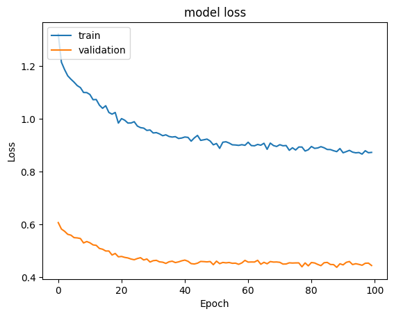

```python
#Plotting Train Loss vs Validation Loss
plt.plot(history_5.history['loss'])
plt.plot(history_5.history['val_loss'])
plt.title('model loss')
plt.ylabel('Loss')
plt.xlabel('Epoch')
plt.legend(['train', 'validation'], loc='upper left')
plt.show()
```

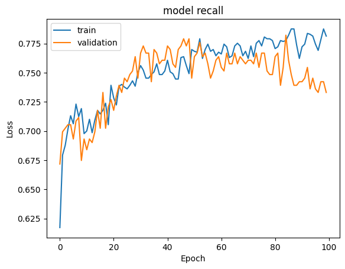

```python
#Plotting Train recall vs Validation recall
plt.plot(history_5.history['recall'])
plt.plot(history_5.history['val_recall'])
plt.title('model recall')
plt.ylabel('Loss')
plt.xlabel('Epoch')
plt.legend(['train', 'validation'], loc='upper left')
plt.show()
```

```python
y_train_pred = model_5.predict(X_train_smote)
#Predicting the results using 0.5 as the threshold
y_train_pred = (y_train_pred > 0.5)
y_train_pred
```

```
319/319 ━━━━━━━━━━━━━━━━━━━━ 1s 2ms/step
```

```
array([[ True],
       [False],
       [False],
       ...,
       [ True],
       [ True],
       [ True]])
```

```python
y_val_pred = model_5.predict(X_val)
#Predicting the results using 0.5 as the threshold
y_val_pred = (y_val_pred > 0.5)
y_val_pred
```

```
50/50 ━━━━━━━━━━━━━━━━━━━━ 0s 1ms/step
```

```
array([[False],
       [False],
       [False],
       ...,
       [False],
       [ True],
       [ True]])
```

```python
model_name = "NN with SMOTE,Adam & Dropout"


train_metric_df.loc[model_name] = recall_score(y_train_smote,y_train_pred)
valid_metric_df.loc[model_name] = recall_score(y_val,y_val_pred)
```

**Classification report**

```python
cr=classification_report(y_train_smote,y_train_pred)
print(cr)
```

```
              precision    recall  f1-score   support

           0       0.82      0.82      0.82      5096
           1       0.82      0.82      0.82      5096

    accuracy                           0.82     10192
   macro avg       0.82      0.82      0.82     10192
weighted avg       0.82      0.82      0.82     10192
```

```python
cr=classification_report(y_val,y_val_pred)
print(cr)
```

```
              precision    recall  f1-score   support

           0       0.92      0.81      0.86      1274
           1       0.50      0.73      0.59       326

    accuracy                           0.80      1600
   macro avg       0.71      0.77      0.73      1600
weighted avg       0.84      0.80      0.81      1600
```

**Confusion matrix**

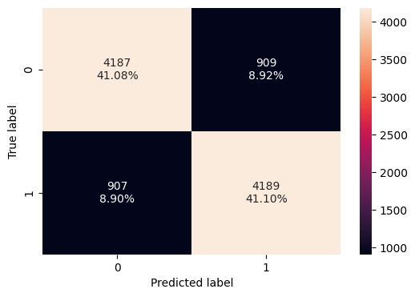

```python
#Calculating the confusion matrix
make_confusion_matrix(y_train_smote, y_train_pred)
```

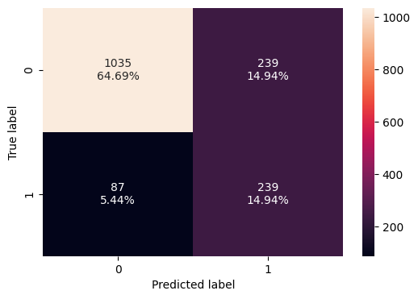

```python
#Calculating the confusion matrix on the validation set
make_confusion_matrix(y_val, y_val_pred)
```

## Model Performance Comparison and Final Model Selection

```python
print("Training performance comparison")
train_metric_df
```

```
Training performance comparison
```

|  | recall |
| --- | --- |
| NN with SGD | 0.70 |
| NN with Adam | 0.80 |
| NN with Adam & Dropout | 0.82 |
| NN with SMOTE & SGD | 0.83 |
| NN with SMOTE & Adam | 0.91 |
| NN with SMOTE,Adam & Dropout | 0.82 |

```python
print("Validation set performance comparison")
valid_metric_df
```

```
Validation set performance comparison
```

|  | recall |
| --- | --- |
| NN with SGD | 0.70 |
| NN with Adam | 0.76 |
| NN with Adam & Dropout | 0.76 |
| NN with SMOTE & SGD | 0.82 |
| NN with SMOTE & Adam | 0.71 |
| NN with SMOTE,Adam & Dropout | 0.73 |

```python
train_metric_df - valid_metric_df
```

|  | recall |
| --- | --- |
| NN with SGD | -0.00 |
| NN with Adam | 0.05 |
| NN with Adam & Dropout | 0.06 |
| NN with SMOTE & SGD | 0.01 |
| NN with SMOTE & Adam | 0.20 |
| NN with SMOTE,Adam & Dropout | 0.09 |

```python
y_test_pred = model_3.predict(X_test)
y_test_pred = (y_test_pred > 0.5)
print(y_test_pred)
```

```
63/63 ━━━━━━━━━━━━━━━━━━━━ 0s 1ms/step
[[False]
 [ True]
 [ True]
 ...
 [ True]
 [ True]
 [ True]]
```

```python
#Print classification report
cr=classification_report(y_test,y_test_pred)
print(cr)
```

```
              precision    recall  f1-score   support

           0       0.92      0.44      0.60      1593
           1       0.28      0.85      0.42       407

    accuracy                           0.52      2000
   macro avg       0.60      0.64      0.51      2000
weighted avg       0.79      0.52      0.56      2000
```

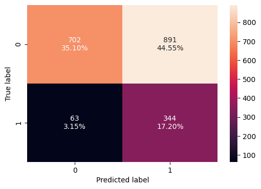

```python
#Calculating the confusion matrix
make_confusion_matrix(y_test,y_test_pred)
```

## Actionable Insights and Business Recommendations

- Less active member leaving more, so customer service should reach to less active member to understand them better and try to resolve to resolve their issues, so that customer can retained
- Above mention model should be used to find out customer who can leave and customer service should approach them
- Should focus on Germany more as customer are leaving more there
- Should focus on female customer also & make them comfortable so that they can be retained